# Tugas Pertemuan 9 - SARIMA

## Library

```r
library(TSA)
library(dplyr)
library(ggplot2)
library(tseries) ## adf.test
library(MASS) ## boxcox
library(forecast)
library(lmtest)
```

## Load Data

Data yang digunakan merupakan data yang berasal dari SIASATI (Sistem Informasi Angkutan dan Saruna Transportasi Indonesia) yang berisi data jumlah penumpang pesawat berangkat dari bandara BPN.

```r
dt <- read.csv("D:\\IPB\\5\\MPDW\\data\\others\\dt_pt3.csv")
head(dt)
```

```
##      Tanggal Penumpang.Berangkat
## 1 2023-08-19                6222
## 2 2023-08-20                6758
## 3 2023-08-21                6542
## 4 2023-08-22                7400
## 5 2023-08-23                7196
## 6 2023-08-24                6663
```

### Preprocessing Data

```r
names(dt) <- c("tanggal","penumpang")
dt$tanggal <- as.Date(dt$tanggal, format = "%Y-%m-%d")
summary(dt)
```

```
##     tanggal             penumpang
##  Min.   :2023-08-19   Min.   :5450
##  1st Qu.:2023-09-16   1st Qu.:6229
##  Median :2023-10-15   Median :6754
##  Mean   :2023-10-15   Mean   :6782
##  3rd Qu.:2023-11-12   3rd Qu.:7300
##  Max.   :2023-12-11   Max.   :8761
```

## Data Keseluruhan

### Visualisasi Data

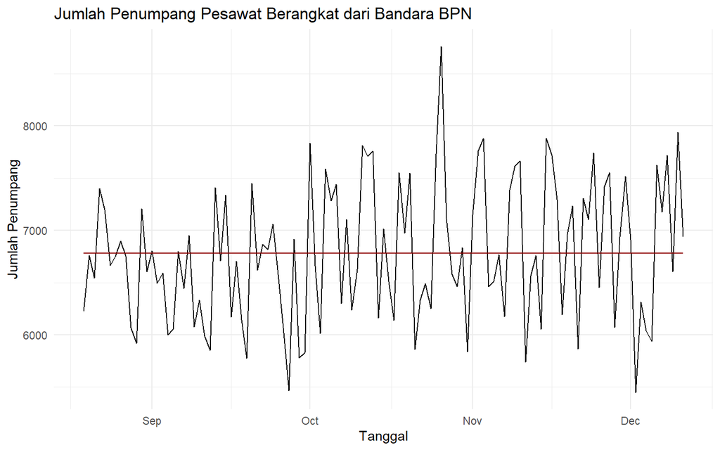

```r
ggplot(dt, aes(x = tanggal, y = penumpang)) +
  geom_line() +
  labs(title = "Jumlah Penumpang Pesawat Berangkat dari Bandara BPN",
       x = "Tanggal",
       y = "Jumlah Penumpang") +
  theme_minimal()+
  geom_line(aes(y = mean(penumpang)),col="darkred")
```

## Train Test Split

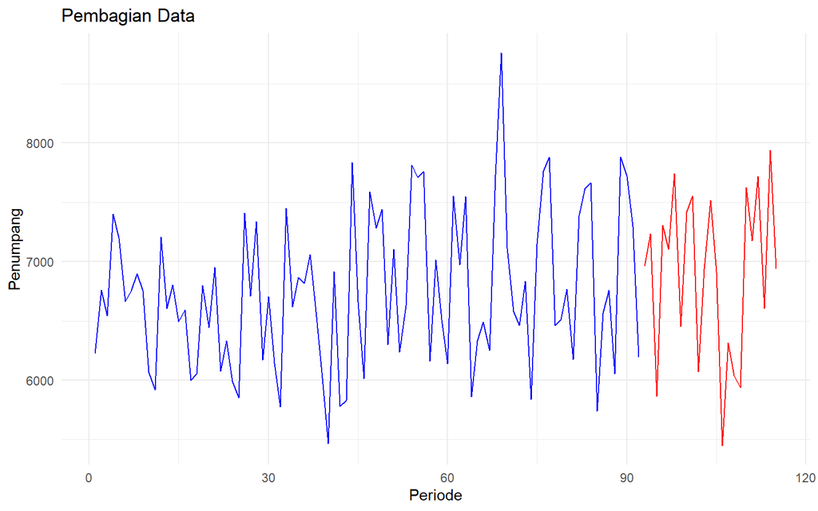

```r
train.ts <- dt$penumpang[1:round(length(dt$penumpang)*0.80)] %>% ts()
test.ts <- dt$penumpang[(round(length(dt$penumpang)*0.80)+1):length(dt$penumpang)] %>% ts()

ggplot()+
  geom_line(aes(x=1:length(train.ts), y=train.ts), color="blue")+
  geom_line(aes(x=(1:length(test.ts)+length(train.ts)), y=test.ts), color="red")+
  labs(title="Pembagian Data",
       x = "Periode",
       y = "Penumpang")+
  theme_minimal()
```

### ACF, PACF, EACF

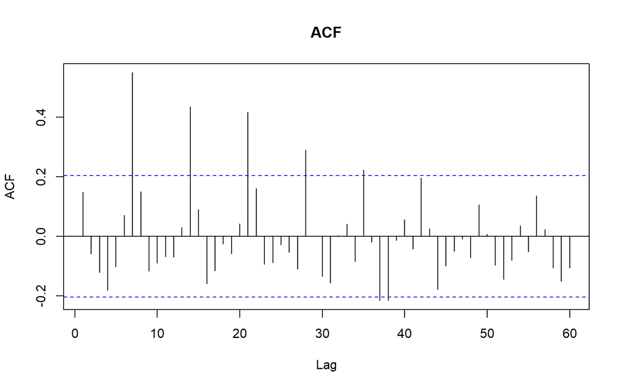

```r
acf(train.ts, main = "ACF",lag.max=60)
```

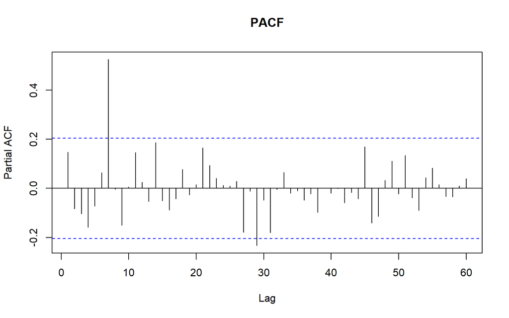

```r
pacf(train.ts, main = "PACF",lag.max=60)
```

```r
eacf(train.ts)
```

```
## AR/MA
##   0 1 2 3 4 5 6 7 8 9 10 11 12 13
## 0 o o o o o o x o o o o  o  o  x
## 1 x o o o o o x x o o o  o  o  x
## 2 x o o o o o x o o o o  o  o  x
## 3 x o x o o o x o o o o  o  o  x
## 4 x x x o o o x o o o o  o  o  x
## 5 x o o o o o x o o o o  o  o  x
## 6 o o x o o o x o o o o  o  o  x
## 7 o x o o o o x o o o o  o  o  o
```

Terlihat dari plot ACF dan PACF bahwa deret waktu memiliki pola yang cenderung seasonal. Kemungkinan besar pola musim yang ada adalah pola mingguan.

Dari hasil EACF kemungkinan model yang cocok adalah ARMA(0,1), ARMA(1,1), atau ARMA(1,2)

Melihat dari pola musiman maka kemungkinan model yang terbentuk adalah ARIMA(0,0,1)(1,0,0)[7], ARIMA(1,0,1)(1,0,0)[7], atau ARIMA(1,0,2)(1,0,0)[7]

### Cek Stasioner dalam Rataan

Untuk mengecek kestasioneran dari rataan kita dapat melihat secara eksploratif dan melakukan Uji Dickey-Fuller.

- $H_0$ : Deret waktu tidak stasioner dalam rataan
- $H_1$ : Deret waktu stasioner dalam rataan

```r
adf.test(train.ts)
```

```
##
##  Augmented Dickey-Fuller Test
##
## data:  train.ts
## Dickey-Fuller = -6.4403, Lag order = 4, p-value = 0.01
## alternative hypothesis: stationary
```

Hasil pengujian mendukung kecenderungan dari eksplorasi data sebelumnya yaitu data stasioner dalam rataan.

### Cek Stasioner dalam Ragam

Untuk mengecek kestasioneran dari ragam kita dapat menggunakan box-cox.

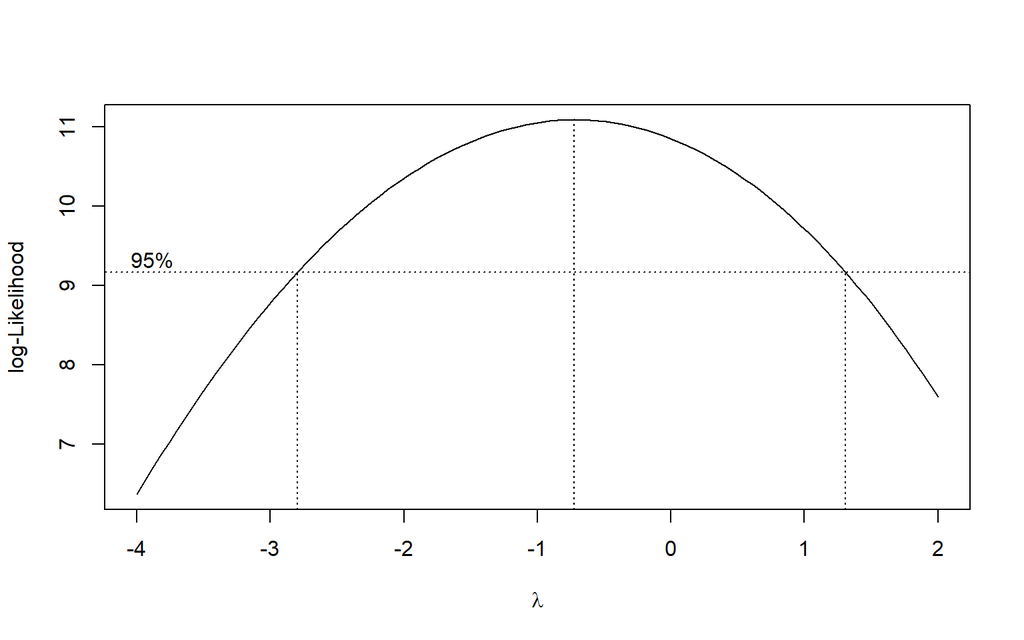

```r
index1 <- c(1:length(train.ts))
bc1 <- boxcox(train.ts~index1, lambda=seq(-4,2,0.1))
```

```r
lambda1 <- bc1$x[which.max(bc1$y)]
lambda1
```

```
## [1] -0.7272727
```

```r
bc1$x[bc1$y > max(bc1$y) - 1/2 * qchisq(0.95,1)] %>% min()
```

```
## [1] -2.787879
```

```r
bc1$x[bc1$y > max(bc1$y) - 1/2 * qchisq(0.95,1)] %>% max()
```

```
## [1] 1.272727
```

Terlihat selang kepercayaan boxcox yaitu **-2.8** hingga **1.27** mengandung nilai 1. Yang berarti ragam dari data stasioner.

## Pemodelan SARIMA

```r
dt.ts <- ts(dt$penumpang)
fit.auto <- auto.arima(train.ts)
fit.auto
```

```
## Series: train.ts
## ARIMA(5,1,3)
##
## Coefficients:
##          ar1      ar2      ar3      ar4      ar5      ma1     ma2      ma3
##       0.1112  -0.7439  -0.1565  -0.2395  -0.4368  -1.0247  0.8756  -0.6583
## s.e.  0.1411   0.1106   0.1312   0.0976   0.1078   0.1471  0.1508   0.1155
##
## sigma^2 = 322837:  log likelihood = -704.32
## AIC=1426.64   AICc=1428.86   BIC=1449.24
```

```r
lmtest::coeftest(fit.auto)
```

```
##
## z test of coefficients:
##
##      Estimate Std. Error z value  Pr(>|z|)
## ar1  0.111206   0.141143  0.7879   0.43076
## ar2 -0.743918   0.110606 -6.7258 1.746e-11 ***
## ar3 -0.156506   0.131225 -1.1927   0.23300
## ar4 -0.239467   0.097586 -2.4539   0.01413 *
## ar5 -0.436809   0.107788 -4.0525 5.067e-05 ***
## ma1 -1.024708   0.147071 -6.9674 3.228e-12 ***
## ma2  0.875562   0.150839  5.8046 6.452e-09 ***
## ma3 -0.658327   0.115518 -5.6989 1.206e-08 ***
## ---
## Signif. codes:  0 '***' 0.001 '**' 0.01 '*' 0.05 '.' 0.1 ' ' 1
```

### SARIMA(0,0,1)(1,0,0)[7]

```r
fit.sarima <- Arima(train.ts, order = c(0,0,1), seasonal = list(order = c(1,0,0), period = 7))
fit.sarima
```

```
## Series: train.ts
## ARIMA(0,0,1)(1,0,0)[7] with non-zero mean
##
## Coefficients:
##          ma1    sar1       mean
##       0.0864  0.5638  6767.3302
## s.e.  0.0982  0.0846   124.3755
##
## sigma^2 = 283696:  log likelihood = -707.92
## AIC=1423.84   AICc=1424.3   BIC=1433.93
```

```r
coeftest(fit.sarima)
```

```
##
## z test of coefficients:
##
##             Estimate Std. Error z value  Pr(>|z|)
## ma1       8.6450e-02 9.8240e-02  0.8800    0.3789
## sar1      5.6379e-01 8.4604e-02  6.6639 2.667e-11 ***
## intercept 6.7673e+03 1.2438e+02 54.4105 < 2.2e-16 ***
## ---
## Signif. codes:  0 '***' 0.001 '**' 0.01 '*' 0.05 '.' 0.1 ' ' 1
```

### SARIMA(1,0,1)(1,0,0)[7]

```r
fit.sarima2 <- Arima(train.ts, order = c(1,0,1), seasonal = list(order = c(1,0,0), period = 7))
fit.sarima2
```

```
## Series: train.ts
## ARIMA(1,0,1)(1,0,0)[7] with non-zero mean
##
## Coefficients:
##          ar1      ma1    sar1      mean
##       0.3241  -0.2225  0.5688  6767.037
## s.e.  0.4596   0.4660  0.0845   132.606
##
## sigma^2 = 285846:  log likelihood = -707.78
## AIC=1425.56   AICc=1426.26   BIC=1438.17
```

```r
coeftest(fit.sarima2)
```

```
##
## z test of coefficients:
##
##              Estimate  Std. Error z value  Pr(>|z|)
## ar1          0.324078    0.459559  0.7052    0.4807
## ma1         -0.222477    0.465967 -0.4775    0.6330
## sar1         0.568830    0.084485  6.7329 1.663e-11 ***
## intercept 6767.036950  132.605994 51.0312 < 2.2e-16 ***
## ---
## Signif. codes:  0 '***' 0.001 '**' 0.01 '*' 0.05 '.' 0.1 ' ' 1
```

### SARIMA(1,0,2)(1,0,0)[7]

```r
fit.sarima3 <- Arima(train.ts, order = c(1,0,2), seasonal = list(order = c(1,0,0), period = 7))
fit.sarima3
```

```
## Series: train.ts
## ARIMA(1,0,2)(1,0,0)[7] with non-zero mean
##
## Coefficients:
##          ar1      ma1     ma2    sar1       mean
##       0.1074  -0.0238  0.1300  0.5883  6766.1491
## s.e.  0.3791   0.3671  0.1452  0.0868   147.6605
##
## sigma^2 = 286257:  log likelihood = -707.45
## AIC=1426.91   AICc=1427.9   BIC=1442.04
```

```r
coeftest(fit.sarima3)
```

```
##
## z test of coefficients:
##
##              Estimate  Std. Error z value  Pr(>|z|)
## ar1          0.107402    0.379097  0.2833    0.7769
## ma1         -0.023780    0.367099 -0.0648    0.9484
## ma2          0.129957    0.145206  0.8950    0.3708
## sar1         0.588279    0.086827  6.7753 1.241e-11 ***
## intercept 6766.149149  147.660451 45.8224 < 2.2e-16 ***
## ---
## Signif. codes:  0 '***' 0.001 '**' 0.01 '*' 0.05 '.' 0.1 ' ' 1
```

### SARIMA(0,0,0)(1,0,0)[7]

```r
fit.sarima4 <- Arima(train.ts, order = c(0,0,0), seasonal = list(order = c(1,0,0), period = 7))
fit.sarima4
```

```
## Series: train.ts
## ARIMA(0,0,0)(1,0,0)[7] with non-zero mean
##
## Coefficients:
##         sar1       mean
##       0.5706  6768.7829
## s.e.  0.0836   116.5686
##
## sigma^2 = 282688:  log likelihood = -708.31
## AIC=1422.61   AICc=1422.89   BIC=1430.18
```

```r
coeftest(fit.sarima4)
```

```
##
## z test of coefficients:
##
##             Estimate Std. Error z value  Pr(>|z|)
## sar1      5.7065e-01 8.3559e-02  6.8293 8.531e-12 ***
## intercept 6.7688e+03 1.1657e+02 58.0669 < 2.2e-16 ***
## ---
## Signif. codes:  0 '***' 0.001 '**' 0.01 '*' 0.05 '.' 0.1 ' ' 1
```

### Pemilihan Model Terbaik

```r
list.model <- c("SARIMA(0,0,1)(1,0,0)[7]","SARIMA(1,0,1)(1,0,0)[7]","SARIMA(1,0,2)(1,0,0)[7]","SARIMA(0,0,0)(1,0,0)[7]")
list.aic <- c(fit.sarima$aic,fit.sarima2$aic,fit.sarima3$aic,fit.sarima4$aic)

data.frame(list.model,list.aic)
```

```
##                list.model list.aic
## 1 SARIMA(0,0,1)(1,0,0)[7] 1423.840
## 2 SARIMA(1,0,1)(1,0,0)[7] 1425.559
## 3 SARIMA(1,0,2)(1,0,0)[7] 1426.909
## 4 SARIMA(0,0,0)(1,0,0)[7] 1422.614
```

Dari hasil pemodelan terlihat bahwa model terbaik adalah SARIMA(0,0,0)(1,0,0)[7] dengan nilai AIC dan seluruh parameter signifikan

### Overfitting

```r
fit.sarima5 <- Arima(train.ts, order = c(1,0,0), seasonal = list(order = c(1,0,0), period = 7))
fit.sarima5
```

```
## Series: train.ts
## ARIMA(1,0,0)(1,0,0)[7] with non-zero mean
##
## Coefficients:
##          ar1    sar1       mean
##       0.0983  0.5643  6767.1326
## s.e.  0.1043  0.0843   126.9688
##
## sigma^2 = 283330:  log likelihood = -707.86
## AIC=1423.73   AICc=1424.19   BIC=1433.82
```

```r
coeftest(fit.sarima2)
```

```
##
## z test of coefficients:
##
##              Estimate  Std. Error z value  Pr(>|z|)
## ar1          0.324078    0.459559  0.7052    0.4807
## ma1         -0.222477    0.465967 -0.4775    0.6330
## sar1         0.568830    0.084485  6.7329 1.663e-11 ***
## intercept 6767.036950  132.605994 51.0312 < 2.2e-16 ***
## ---
## Signif. codes:  0 '***' 0.001 '**' 0.01 '*' 0.05 '.' 0.1 ' ' 1
```

```r
fit.sarima6 <- Arima(train.ts, order = c(0,0,1), seasonal = list(order = c(1,0,0), period = 7))
fit.sarima6
```

```
## Series: train.ts
## ARIMA(0,0,1)(1,0,0)[7] with non-zero mean
##
## Coefficients:
##          ma1    sar1       mean
##       0.0864  0.5638  6767.3302
## s.e.  0.0982  0.0846   124.3755
##
## sigma^2 = 283696:  log likelihood = -707.92
## AIC=1423.84   AICc=1424.3   BIC=1433.93
```

```r
coeftest(fit.sarima6)
```

```
##
## z test of coefficients:
##
##             Estimate Std. Error z value  Pr(>|z|)
## ma1       8.6450e-02 9.8240e-02  0.8800    0.3789
## sar1      5.6379e-01 8.4604e-02  6.6639 2.667e-11 ***
## intercept 6.7673e+03 1.2438e+02 54.4105 < 2.2e-16 ***
## ---
## Signif. codes:  0 '***' 0.001 '**' 0.01 '*' 0.05 '.' 0.1 ' ' 1
```

```r
fit.sarima7 <- Arima(train.ts, order = c(0,0,0), seasonal = list(order = c(2,0,0), period = 7))
fit.sarima7
```

```
## Series: train.ts
## ARIMA(0,0,0)(2,0,0)[7] with non-zero mean
##
## Coefficients:
##         sar1    sar2       mean
##       0.4373  0.2294  6771.7979
## s.e.  0.1003  0.1049   134.7766
##
## sigma^2 = 269864:  log likelihood = -706.02
## AIC=1420.03   AICc=1420.49   BIC=1430.12
```

```r
coeftest(fit.sarima7)
```

```
##
## z test of coefficients:
##
##             Estimate Std. Error z value  Pr(>|z|)
## sar1         0.43733    0.10034  4.3585  1.31e-05 ***
## sar2         0.22942    0.10489  2.1872   0.02873 *
## intercept 6771.79786  134.77660 50.2446 < 2.2e-16 ***
## ---
## Signif. codes:  0 '***' 0.001 '**' 0.01 '*' 0.05 '.' 0.1 ' ' 1
```

```r
fit.sarima8 <- Arima(train.ts, order = c(0,0,0), seasonal = list(order = c(1,0,1), period = 7))
fit.sarima8
```

```
## Series: train.ts
## ARIMA(0,0,0)(1,0,1)[7] with non-zero mean
##
## Coefficients:
##         sar1     sma1       mean
##       0.9173  -0.5881  6768.1725
## s.e.  0.0590   0.1330   163.4136
##
## sigma^2 = 252681:  log likelihood = -703.76
## AIC=1415.51   AICc=1415.97   BIC=1425.6
```

```r
coeftest(fit.sarima8)
```

```
##
## z test of coefficients:
##
##              Estimate  Std. Error z value  Pr(>|z|)
## sar1         0.917298    0.059033 15.5386 < 2.2e-16 ***
## sma1        -0.588141    0.132956 -4.4236 9.707e-06 ***
## intercept 6768.172503  163.413621 41.4174 < 2.2e-16 ***
## ---
## Signif. codes:  0 '***' 0.001 '**' 0.01 '*' 0.05 '.' 0.1 ' ' 1
```

### Modelling

```r
fit.sarima8
```

```
## Series: train.ts
## ARIMA(0,0,0)(1,0,1)[7] with non-zero mean
##
## Coefficients:
##         sar1     sma1       mean
##       0.9173  -0.5881  6768.1725
## s.e.  0.0590   0.1330   163.4136
##
## sigma^2 = 252681:  log likelihood = -703.76
## AIC=1415.51   AICc=1415.97   BIC=1425.6
```

### Eksplorasi Sisaan

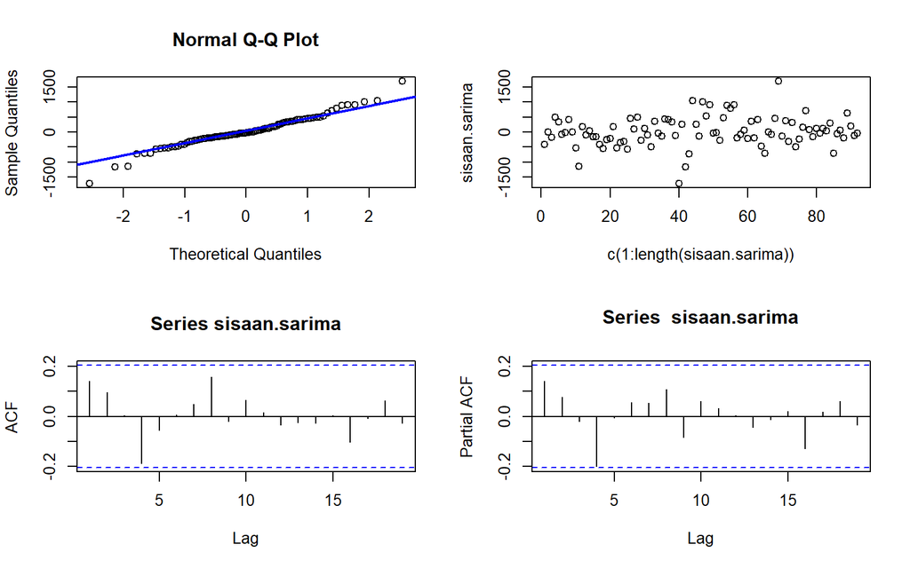

```r
sisaan.sarima <- fit.sarima8$residuals
par(mfrow=c(2,2))
qqnorm(sisaan.sarima)
qqline(sisaan.sarima, col = "blue", lwd = 2)
plot(c(1:length(sisaan.sarima)),sisaan.sarima)
acf(sisaan.sarima)
pacf(sisaan.sarima)
```

```r
par(mfrow = c(1,1))
```

### Uji Formal

```r
ks.test(sisaan.sarima,"pnorm")
```

```
##
##  Exact one-sample Kolmogorov-Smirnov test
##
## data:  sisaan.sarima
## D = 0.55434, p-value = 3.331e-16
## alternative hypothesis: two-sided
```

tolak H0 sehingga sisaan tidak normal

```r
#2) Sisaan saling bebas/tidak ada autokorelasi
Box.test(sisaan.sarima, type = "Ljung")
```

```
##
##  Box-Ljung test
##
## data:  sisaan.sarima
## X-squared = 1.8613, df = 1, p-value = 0.1725
```

```r
#tak tolak H0 > sisaan saling bebas
```

```r
#3) Sisaan homogen
Box.test((sisaan.sarima)^2, type = "Ljung")
```

```
##
##  Box-Ljung test
##
## data:  (sisaan.sarima)^2
## X-squared = 0.020182, df = 1, p-value = 0.887
```

```r
#tak tolak H0 > sisaan homogen
```

Ragam Homogen

```r
#4) Nilai tengah sisaan sama dengan nol
t.test(sisaan.sarima, mu = 0, conf.level = 0.95)
```

```
##
##  One Sample t-test
##
## data:  sisaan.sarima
## t = 0.37079, df = 91, p-value = 0.7117
## alternative hypothesis: true mean is not equal to 0
## 95 percent confidence interval:
##  -83.67002 122.07578
## sample estimates:
## mean of x
##  19.20288
```

```r
#tak tolak h0 > nilai tengah sisaan sama dengan 0
```

Nilai tengah sisaan sama dengan 0

### Kesimpulan

Model terbaik adalah model SARMA (1,0,1)[7] namun tidak memenuhi asumsi sisaan menyebar normal. Namun asumsi ini dapat kita abaiakan karena tidak berpengaruh ke permalana.

## Forecasting

Karena model yang kita miliki sudah sesuai, kita dapat melakukan forecasting.

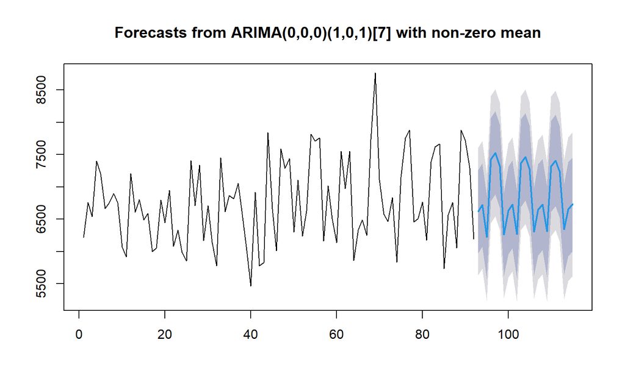

```r
hasil.forecast <- forecast::forecast(fit.sarima8,h=length(test.ts))
plot(hasil.forecast)
```

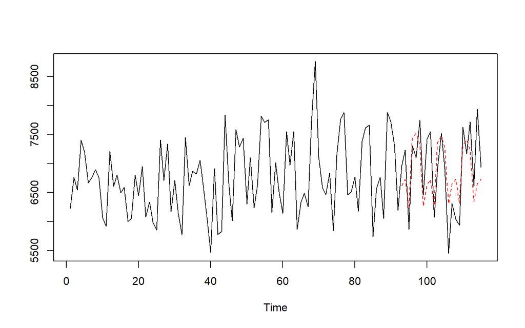

```r
dt.ts <- ts(dt$penumpang)
ts.plot(dt.ts,hasil.forecast$mean, col = c("black","red"), lty = c(1,2))
```

```r
accuracy(ts(hasil.forecast$mean),ts(test.ts))
```

```
##                ME     RMSE      MAE       MPE     MAPE      ACF1 Theil's U
## Test set 55.31282 518.2824 436.7688 0.2309416 6.362239 0.3481758  0.534261
```

Hasil prediksi menunjukan MAPE sebesar 6% yang menunjukan hasil peramalan yang cukup baik.